# Intro to R Markdown

Claus O. Wilke

Much of the work in this class will be done via R Markdown documents. R Markdown documents are documents that combine text, R code, and R output, including figures. They are a great way to produce self-contained and documented statistical analyses.

In this first worksheet, you will learn how to do some basic markdown editing. After you have made a change to the document, press “Knit HTML” in R Studio and see what kind of a result you get.

Edit only below this line.

## 1. Basic Markdown editing

Try out basic R Markdown features, as described here: https://rmarkdown.rstudio.com/authoring_basics.html. Write some text that is bold, and some that is in italics. Make a numbered list and a bulleted list. Make a nested list. Try the block-quote feature.

## 2. Embedding R code

R code embedded in R chunks will be executed and the output will be shown.

```r
# R code goes here
x <- rnorm(100)  # random sample from normal distribution
dens <- density(x)    # calculate density
dens
```

```
##
## Call:
##  density.default(x = x)
##
## Data: x (100 obs.);  Bandwidth 'bw' = 0.2947
##
##        x                 y
##  Min.   :-2.8257   Min.   :0.0001523
##  1st Qu.:-1.3204   1st Qu.:0.0191141
##  Median : 0.1849   Median :0.1288127
##  Mean   : 0.1849   Mean   :0.1659141
##  3rd Qu.: 1.6902   3rd Qu.:0.2919876
##  Max.   : 3.1955   Max.   :0.4502133
```

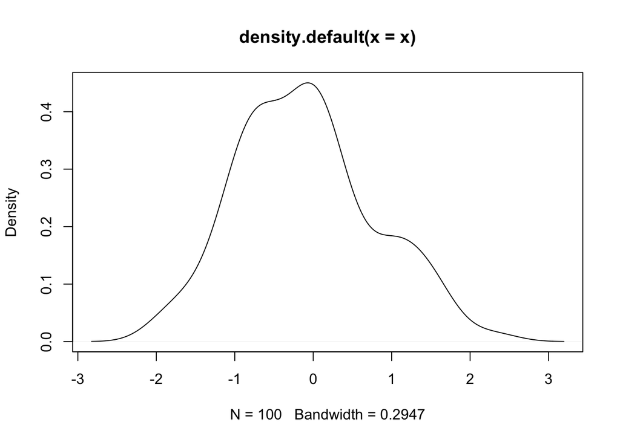

```r
plot(dens)            # plot density
```

Now you try it. For example, take the built-in data set `cars`, which lists speed and stopping distance for cars from the 1920. Plot speed vs. distance, and/or perform a correlation analysis. Then write a few sentences describing what you see.

This is a sentence in Markdown, containing `code`, **bold text**, and *italics*.